# Análise exploratória de carros a venda

[figure not shown]

# 1. Introdução

Automóvel (do grego αὐτός ["autós"], "por si próprio", e do latim mobilis, "mobilidade", como referência a um objeto responsável pela sua própria locomoção ou de outras pessoas em consoante) ou carro (das línguas celtas, através do latim carru)[1] é um veículo motorizado com rodas usado para transporte. Os carros entraram em uso global durante o século XX e as economias desenvolvidas dependem deles. O ano de 1886 é considerado como o ano de nascimento do carro moderno, quando o inventor alemão Karl Benz patenteou seu Benz Patent-Motorwagen.

Neste estudo iremos analisar os carros a venda no norte da américa, os dados foram obtidos do kaggle.com, a base contem 28 marcas de veiculos a venda e suas caracteristicas nos Estados Unidos e Canada.

# 1.1. Objetivos

O objetivo deste estudo é realizar uma análise exploratória dos dados do conjunto, a fim de caracterizar os carros a leilão. Especificiamente serão respondidas as seguintes questões de pesquisa:

- Qual marca tem mais carros a venda?
- Qual modelo possui mais unidades venda?
- Quais anos tiveram maior numero de carros?
- Qual ano possui carros em melhores condições?
- Qual marca possui maior numero de carros em condições ruins?
- Quais modelos possuem menos milhas?
- Quais caracteristicas podem oferecer carros que terão menor possibilidade de apresentar problemas?

# 2. Metodologia

Nesta seção será apresentado todo o processo de preparação, organização e limpeza de dados feito no dataset que possui os seguintes dados:

| Coluna | Descrição | Tipo |
| --- | --- | --- |
| Price | Valor do veiculo a venda | Integer |
| Years | Ano de registro do veiculo | Integer |
| Brand | Marca do carro | String |
| Model | Modelo do veiculo | String |
| Color | Cor do veiculo | String |
| State/City | Cidade/pais onde o carro está localizado | String |
| Mileage | Milhas percorridas pelo carro | Float |
| Vin | Identificação númerica do veiculo | integer |
| Title Status | Classificação do veiculo | String |
| Lot | Numero de identificação do lote | Integer |
| Condition | Tempo em que o carro está venda | String |

## OBSERVAÇÕES

Title Status: clean vehicles e salvage insurance  
Lot: é um numero atribuido a uma quantidade especifica de carros produzidos

# 2.1. Configuração do Ambiente

```python
import pandas as pd
import numpy as np
import matplotlib.pyplot as plt
import seaborn as sns
from pandasql import sqldf
pysqldf = lambda q: sqldf(q, globals())
pd.options.mode.chained_assignment = None  # default='warn'
pd.set_option('display.max_columns', None)
pd.options.display.float_format = '{:,.2f}'.format
sns.set(rc={'figure.figsize':(7,5)})
```

# 2.2. Leitura dos Dados

```python
df = pd.read_csv('USA_cars_datasets.csv')
```

```python
df.head()
```

|  | Unnamed: 0 | price | brand | model | year | title_status | mileage | color | vin | lot | state | country | condition |
| --- | --- | --- | --- | --- | --- | --- | --- | --- | --- | --- | --- | --- | --- |
| 0 | 0 | 6300 | toyota | cruiser | 2008 | clean vehicle | 274,117.00 | black | jtezu11f88k007763 | 159348797 | new jersey | usa | 10 days left |
| 1 | 1 | 2899 | ford | se | 2011 | clean vehicle | 190,552.00 | silver | 2fmdk3gc4bbb02217 | 166951262 | tennessee | usa | 6 days left |
| 2 | 2 | 5350 | dodge | mpv | 2018 | clean vehicle | 39,590.00 | silver | 3c4pdcgg5jt346413 | 167655728 | georgia | usa | 2 days left |
| 3 | 3 | 25000 | ford | door | 2014 | clean vehicle | 64,146.00 | blue | 1ftfw1et4efc23745 | 167753855 | virginia | usa | 22 hours left |
| 4 | 4 | 27700 | chevrolet | 1500 | 2018 | clean vehicle | 6,654.00 | red | 3gcpcrec2jg473991 | 167763266 | florida | usa | 22 hours left |

```python
df.info()
```

```
<class 'pandas.core.frame.DataFrame'>
RangeIndex: 2499 entries, 0 to 2498
Data columns (total 13 columns):
 #   Column        Non-Null Count  Dtype
---  ------        --------------  -----
 0   Unnamed: 0    2499 non-null   int64
 1   price         2499 non-null   int64
 2   brand         2499 non-null   object
 3   model         2499 non-null   object
 4   year          2499 non-null   int64
 5   title_status  2499 non-null   object
 6   mileage       2499 non-null   float64
 7   color         2499 non-null   object
 8   vin           2499 non-null   object
 9   lot           2499 non-null   int64
 10  state         2499 non-null   object
 11  country       2499 non-null   object
 12  condition     2499 non-null   object
dtypes: float64(1), int64(4), object(8)
memory usage: 253.9+ KB
```

```python
df.describe()
```

|  | Unnamed: 0 | price | year | mileage | lot |
| --- | --- | --- | --- | --- | --- |
| count | 2,499.00 | 2,499.00 | 2,499.00 | 2,499.00 | 2,499.00 |
| mean | 1,249.00 | 18,767.67 | 2,016.71 | 52,298.69 | 167,691,389.06 |
| std | 721.54 | 12,116.09 | 3.44 | 59,705.52 | 203,877.21 |
| min | 0.00 | 0.00 | 1,973.00 | 0.00 | 159,348,797.00 |
| 25% | 624.50 | 10,200.00 | 2,016.00 | 21,466.50 | 167,625,331.00 |
| 50% | 1,249.00 | 16,900.00 | 2,018.00 | 35,365.00 | 167,745,058.00 |
| 75% | 1,873.50 | 25,555.50 | 2,019.00 | 63,472.50 | 167,779,772.00 |
| max | 2,498.00 | 84,900.00 | 2,020.00 | 1,017,936.00 | 167,805,500.00 |

# 2.3. Organização e Limpeza dos Dados

## 2.3.1. Tranformando dados

```python
df['year'] = df['year'].astype(int)

df['lot'] = df['lot'].astype(str)
```

# 2.3.2 Remoção de Colunas

Removendo as colunas:

- Unnamed: 0, pois se trata de um index
- vin, pois é uma identificação númerica sem utilidade

```python
df.drop(columns=['Unnamed: 0','vin'], inplace=True)
```

## 2.3.3. Dados Ausentes

### Temos carros com preço zerados

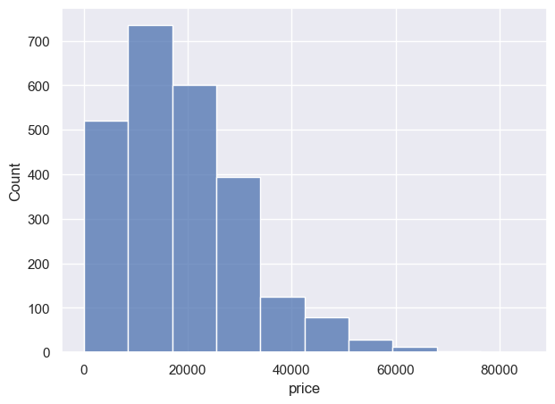

```python
sns.histplot(df.price, bins=10)
```

```python
df['price'] = df['price'].fillna(df['price'].mean())
```

# 2.4. Mapeamento de Dados

Para melhorar a análise e interpretação dos dados os seguintes atributos serão modificados:

[output not shown]

```python
df['title_status'] = np.where(df['title_status'] == 'clean vehicle'	, 'Bom', "Ruim")
```

# 2.5. Feature Engineering

A engenharia de recursos (Feature Engineering) é o processo de usar o conhecimento do domínio para extrair recursos dos dados brutos. Neste estudo serão acrescentadas as seguintes colunas para enriquecer a análise de dados:

| Coluna | Descrição |
| --- | --- |
| condition | Separação da coluna por espaço para pegar o numero e grandeza (horas, dias) |

```python
df['split'] = df['condition'].str.split()

df['Numero'] = 0
df['grandeza'] = 0

for i in df.index:

    df['Numero'][i] = df['split'][i][0]
    df['grandeza'][i] = df['split'][i][1]
```

```python
df.drop(columns = ['split'], inplace=True)
```

# 3. Análise dos Dados

## 3.1. Qual marca tem mais carros a venda?

```python
marca_maior = df.groupby(by='brand').aggregate({'price':'count'}).reset_index().rename(columns= {'price':'Qtd'}).sort_values('Qtd', ascending=False).head(10)
```

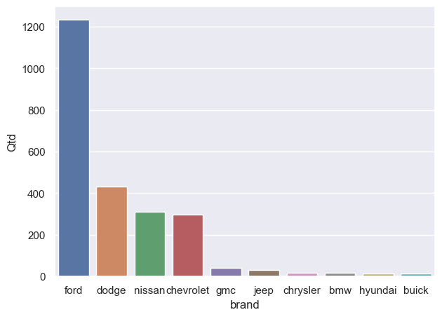

```python
sns.barplot(x = marca_maior['brand'], y =marca_maior['Qtd'] )
```

Respostas: **Ford** e **Dodge**

## 3.2. Qual modelo possui mais unidades venda?

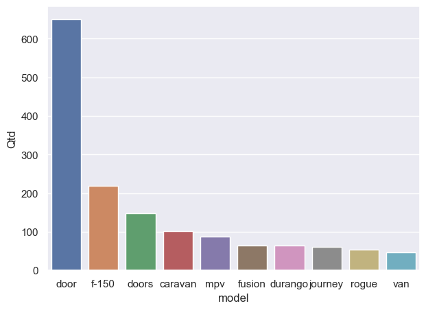

```python
vei_maior = df.groupby(by='model').aggregate({'price':'count'}).reset_index().rename(columns= {'price':'Qtd'}).sort_values('Qtd', ascending=False).head(10)

sns.barplot(x = vei_maior['model'], y = vei_maior['Qtd'] )
```

Resposta: **door**

## 3.3. Quais anos tiveram maior numero de carros?

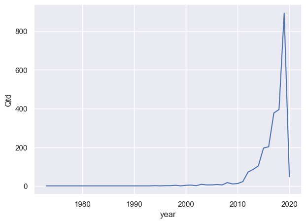

```python
vei_maior = df.groupby(by='year').aggregate({'price':'count'}).reset_index().rename(columns= {'price':'Qtd'}).sort_values('Qtd', ascending=False)

sns.lineplot(x = vei_maior['year'], y = vei_maior['Qtd'] )
```

Resposta: **2018 e 2019**

## 3.4. Qual ano possui carros em piores condições?

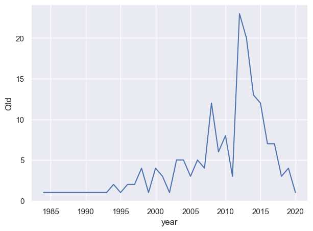

```python
df2 = df[df['title_status'] != 'Bom'	]

vei_maior = df2.groupby(by=['year' ]).aggregate({'price':'count'}).reset_index().rename(columns= {'price':'Qtd'}).sort_values('Qtd', ascending=False)

sns.lineplot(x = vei_maior['year'], y = vei_maior['Qtd'] )
```

Resposta: **2012**

## 3.5. Qual marca possui maior numero de carros em condições ruins?

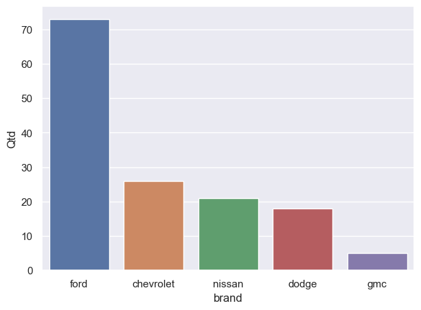

```python
df2 = df[df['title_status'] != 'Bom'	]

vei_maior = df2.groupby(by=['brand']).aggregate({'price':'count'}).reset_index().rename(columns= {'price':'Qtd'}).sort_values('Qtd', ascending=False).head(5)


plt.subplot

sns.barplot(x = vei_maior['brand'], y = vei_maior['Qtd'] )
```

Resposta: **Ford**

## 3.6. Quais modelos com mais milhas rodadas?

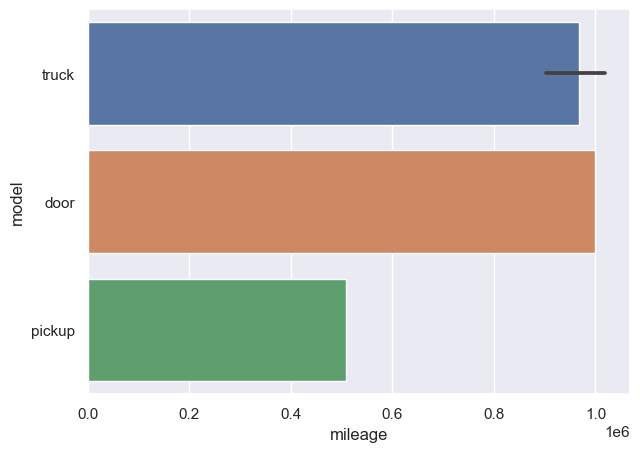

```python
vei_maior = df.sort_values('mileage', ascending=False).head(5)

sns.barplot(x = vei_maior['mileage'], y = vei_maior['model'], orient='h' )
```

Respota: **Truck**

## 3.7. Quais caracteristicas tem uma melhor possibilidade de oferecer carro que não apresentará problemas futuramente?

```python
df['Count'] = 1

df['Ruim'] = np.where(df['title_status'] == 'Ruim', 1,0)

df_clean = df[df['title_status'] == 'Bom']

df_no_clean = df[df['title_status'] == 'Ruim']
```

### 3.7.1 Quantidade de carro por Ano e Status

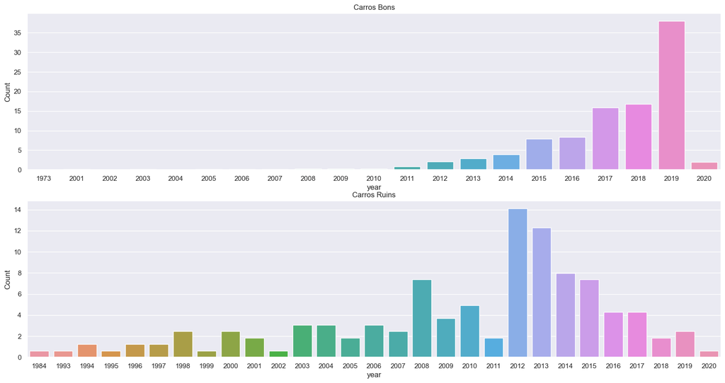

```python
ano_ruim = df_no_clean.groupby('year').agg({'Count': 'sum'})

ano_bom = df_clean.groupby('year').agg({'Count': 'sum'})

fig, ((a),(b)) = plt.subplots(2,1,figsize = (20,10))

sns.barplot(x = ano_bom.index, y = (ano_bom['Count'] / ano_bom['Count'].sum()) * 100, ax=a)
a.set_title('Carros Bons')


sns.barplot(x = ano_ruim.index, y = (ano_ruim['Count'] / ano_ruim['Count'].sum()) * 100, ax=b)
b.set_title('Carros Ruins')


fig.show()
```

Os anos de 2008 e 2012 até 2015 apresentaram o maior porcentagem de carros ruins (Maior que 7% do total de 163)

### 3.7.2 Quantidade de carro por marca

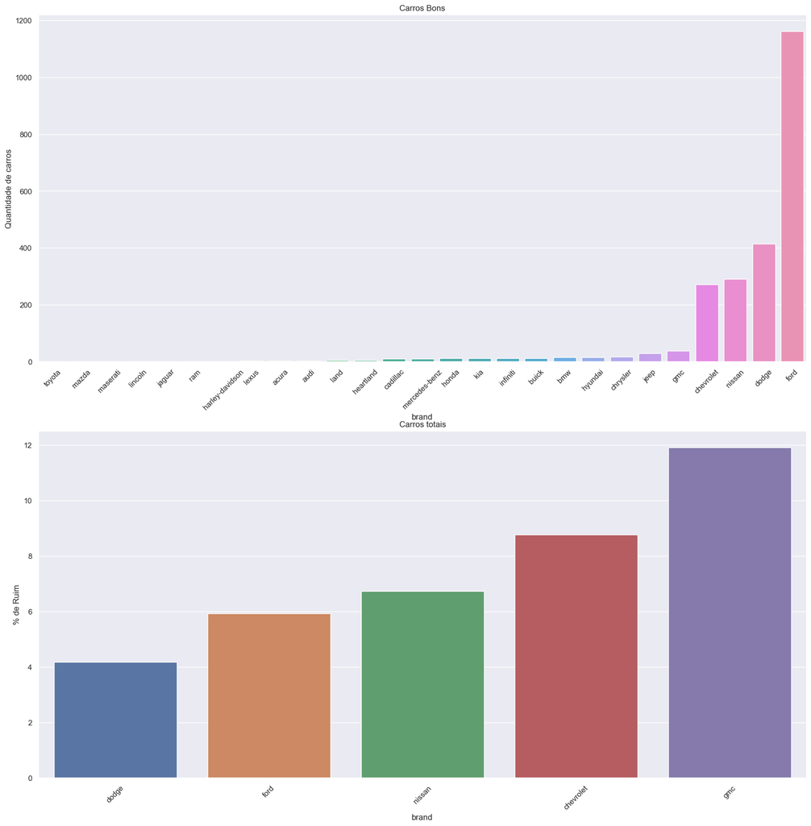

```python
ano_ruim = df_no_clean.groupby('brand').agg({'Count': 'sum'}).sort_values('Count')
ano_bom = df_clean.groupby('brand').agg({'Count': 'sum'}).sort_values('Count')

df_total = df.groupby('brand' ).agg({'Count': 'count', 'Ruim':'sum'}).reset_index()
df_total['% de Ruim'] = df_total['Ruim'] / df_total['Count'] *100
df_total.replace([np.inf, -np.inf], 0, inplace=True)
df_total = df_total.sort_values(['Count','% de Ruim'], ascending=False).head(5)

fig, ((a),(b)) = plt.subplots(2,1, figsize = (20,20))

sns.barplot(x = ano_bom.index, y = ano_bom['Count'], ax=a)
a.set_title('Carros Bons')
a.set_xticklabels(a.get_xticklabels(),rotation = 45)
a.set(ylabel='Quantidade de carros')


sns.barplot(data = df_total.sort_values('% de Ruim'), x = 'brand', y = '% de Ruim' ,  ax=b)
b.set_title('Carros totais')
b.set_xticklabels(b.get_xticklabels(),rotation = 45)


fig.show()
```

Dentro os Top 5 marcas de carro mais produzidas a Ford e a Dodge tem a menor incidencia de carros ruins

### 3.7.3 Quantidade de carro por modelo

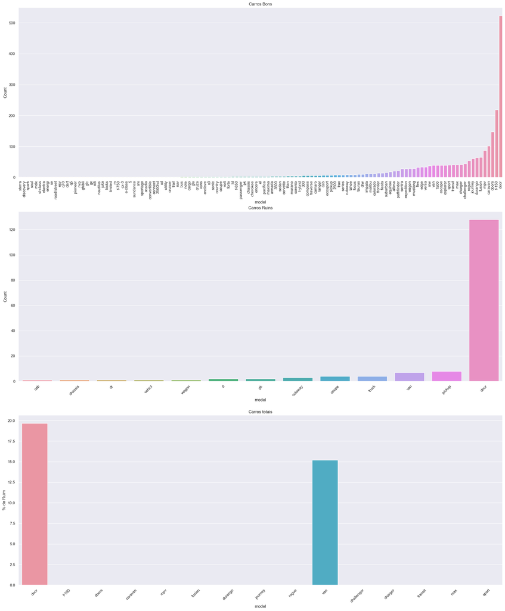

```python
ano_ruim = df_no_clean.groupby('model').agg({'Count': 'sum'}).sort_values('Count')
ano_bom = df_clean.groupby('model').agg({'Count': 'sum'}).sort_values('Count')

df_total = df.groupby('model' ).agg({'Count': 'count', 'Ruim':'sum'}).reset_index()
df_total['% de Ruim'] = df_total['Ruim'] / df_total['Count'] *100
df_total.replace([np.inf, -np.inf], 0, inplace=True)
df_total = df_total.sort_values('Count', ascending=False).head(15)


fig, ((a),(b), (c)) = plt.subplots(3,1, figsize = (25,30))

sns.barplot(x = ano_bom.index, y = ano_bom['Count'], ax=a)
a.set_title('Carros Bons')
a.set_xticklabels(a.get_xticklabels(),rotation = 90)

sns.barplot(x = ano_ruim.index, y = ano_ruim['Count'], ax=b)
b.set_title('Carros Ruins')
b.set_xticklabels(b.get_xticklabels(),rotation = 45)

sns.barplot(x = df_total['model'], y = df_total['% de Ruim'] ,  ax=c)
c.set_title('Carros totais')
c.set_xticklabels(c.get_xticklabels(),rotation = 45)


fig.show()
```

Os modelo parecem não terem alguma ligação com os carros ruins

### 3.7.4 Volume de carros por Milhas e Status

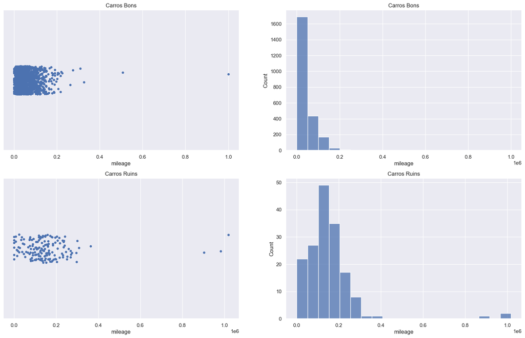

```python
fig, ((a,b),(c,d)) = plt.subplots(2,2, figsize = (20,12))

sns.stripplot(x = df_clean['mileage'], ax=a)
a.set_title('Carros Bons')
a.set_xticklabels(a.get_xticklabels())

sns.histplot(df_clean['mileage'],bins= 20, ax=b)
b.set_title('Carros Bons')

sns.stripplot(x= df_no_clean['mileage'], ax=c)
c.set_title('Carros Ruins')

sns.histplot(df_no_clean['mileage'],bins= 20, ax=d)
d.set_title('Carros Ruins')

fig.show()
```

```python
print('Mediana do Km/s rodados: ' , df_clean['mileage'].median(0), '\n',
'Mediana do Km/s rodados: ' , df_no_clean['mileage'].median(0))
```

```
Mediana do Km/s rodados:  34151.0
 Mediana do Km/s rodados:  137422.0
```

O carros ruins tem uma mediana muito superior aos bons e com pouquisimos outlier, é bem seguro dizer que carro acima de 100.000 mileage rodados tem uma alta probabilidade de serem carros ruins.

### 3.7.5 Quantidade de carros por cor e Status

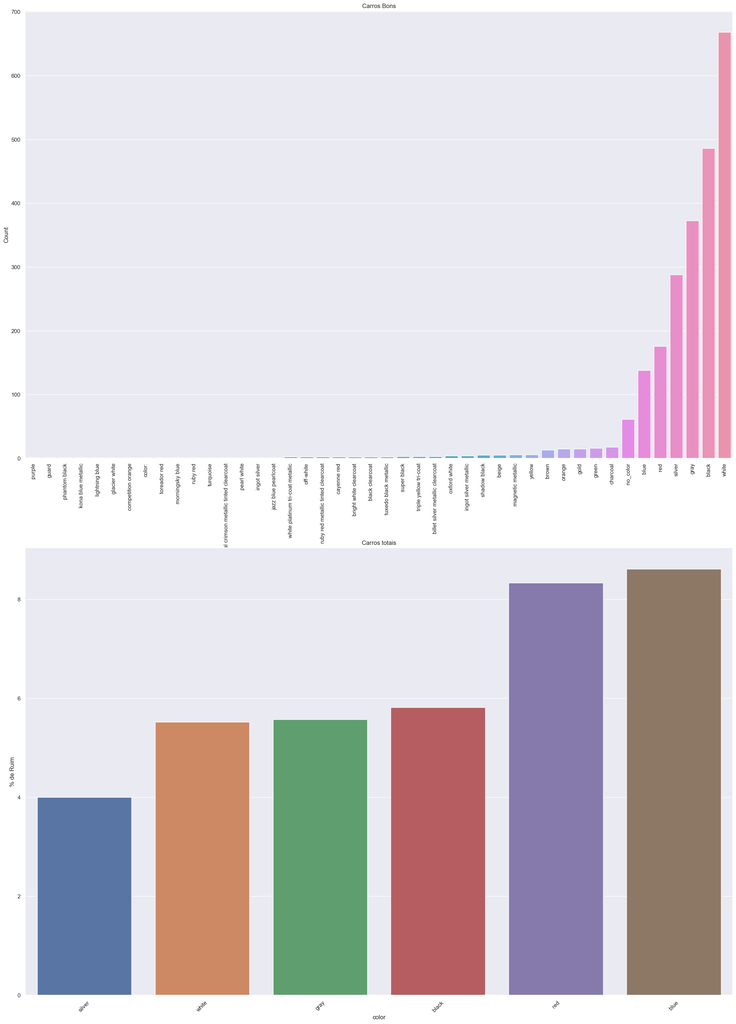

```python
ano_ruim = df_no_clean.groupby('color').agg({'Count': 'sum'}).sort_values('Count')
ano_bom = df_clean.groupby('color').agg({'Count': 'sum'}).sort_values('Count')

df_total = df.groupby('color' ).agg({'Count': 'count', 'Ruim':'sum'}).reset_index()
df_total['% de Ruim'] = df_total['Ruim'] / df_total['Count'] *100
df_total.replace([np.inf, -np.inf], 0, inplace=True)
df_total = df_total.sort_values('Count', ascending=False).head(6)


fig, ((a),(b)) = plt.subplots(2,1, figsize = (25,35))

sns.barplot(data = ano_bom, x = ano_bom.index, y = 'Count', ax=a)
a.set_title('Carros Bons')
a.set_xticklabels(a.get_xticklabels(),rotation = 90)

sns.barplot(data = df_total.sort_values('% de Ruim'), x = 'color', y = '% de Ruim' ,  ax=b)
b.set_title('Carros totais')
b.set_xticklabels(b.get_xticklabels(),rotation = 45)


fig.show()
```

### 3.7.6 Quantidade de carros por Cidade e Status

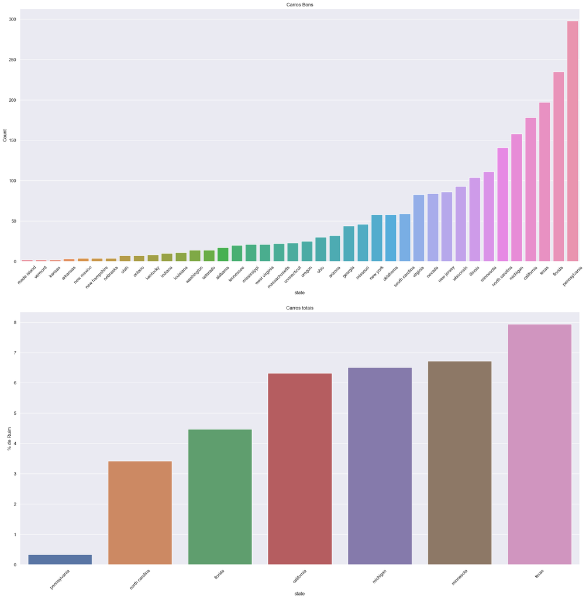

```python
ano_ruim = df_no_clean.groupby('state').agg({'Count': 'sum'}).sort_values('Count')
ano_bom = df_clean.groupby('state').agg({'Count': 'sum'}).sort_values('Count')

df_total = df.groupby('state' ).agg({'Count': 'count', 'Ruim':'sum'}).reset_index()
df_total['% de Ruim'] = df_total['Ruim'] / df_total['Count'] *100
df_total.replace([np.inf, -np.inf], 0, inplace=True)
df_total = df_total.sort_values('Count', ascending=False).head(7)


fig, ((a),(b)) = plt.subplots(2,1, figsize = (25,25))

sns.barplot(x = ano_bom.index, y = ano_bom['Count'], ax=a)
a.set_title('Carros Bons')
a.set_xticklabels(a.get_xticklabels(),rotation = 45)

sns.barplot(data = df_total.sort_values('% de Ruim'), x = 'state', y = '% de Ruim' ,  ax=b)
b.set_title('Carros totais')
b.set_xticklabels(b.get_xticklabels(),rotation = 45)


fig.show()
```

O estado da Pennsylvania apresentou menor indice de carros ruins

# Conclusão

## Critérios escolhidos

| **Condições** | **Critérios** |
| --- | --- |
| **ANO:** | Maior que 2015 |
| **Marca:** | Ford e Dodge |
| **Modelo:** | Sem critérios |
| **Mileage:** | Menor que 100.000 |
| **Color:** | Silver e white |
| **State:** | Pennsylvania |
| **Condition:** | Sem critérios |

```python
pysqldf(""" select * from df_clean
where year > 2015
and brand in ('ford', 'dodge')
and mileage < 100000
and state = 'pennsylvania'
and color in ('silver', 'white')
order by price asc
limit 10


""")
```

|  | price | brand | model | year | title_status | mileage | color | lot | state | country | condition | Numero | grandeza | Count | Ruim |
| --- | --- | --- | --- | --- | --- | --- | --- | --- | --- | --- | --- | --- | --- | --- | --- |
| 0 | 6200 | dodge | door | 2016 | Bom | 66,167.00 | silver | 167773297 | pennsylvania | usa | 2 days left | 2 | days | 1 | 0 |
| 1 | 9200 | ford | door | 2017 | Bom | 57,853.00 | white | 167605912 | pennsylvania | usa | 1 days left | 1 | days | 1 | 0 |
| 2 | 10700 | ford | van | 2016 | Bom | 99,544.00 | white | 167606942 | pennsylvania | usa | 1 days left | 1 | days | 1 | 0 |
| 3 | 13200 | dodge | caravan | 2018 | Bom | 41,014.00 | silver | 167748926 | pennsylvania | usa | 3 days left | 3 | days | 1 | 0 |
| 4 | 13700 | ford | van | 2016 | Bom | 67,150.00 | white | 167773301 | pennsylvania | usa | 2 days left | 2 | days | 1 | 0 |
| 5 | 14000 | ford | fusion | 2018 | Bom | 50,513.00 | white | 167749355 | pennsylvania | usa | 2 days left | 2 | days | 1 | 0 |
| 6 | 14300 | ford | edge | 2016 | Bom | 69,428.00 | white | 167606685 | pennsylvania | usa | 1 days left | 1 | days | 1 | 0 |
| 7 | 14500 | dodge | door | 2016 | Bom | 82,240.00 | white | 167773290 | pennsylvania | usa | 21 hours left | 21 | hours | 1 | 0 |
| 8 | 14700 | dodge | caravan | 2019 | Bom | 44,381.00 | silver | 167744811 | pennsylvania | usa | 2 days left | 2 | days | 1 | 0 |
| 9 | 15000 | dodge | journey | 2018 | Bom | 38,029.00 | white | 167612012 | pennsylvania | usa | 6 days left | 6 | days | 1 | 0 |